El siguiente trabajo propone un modelo que permita predecir si un paciente puede ser o no hospitalizado dado que ya tiene un dengue, además de esto teniendo en cuenta que tipo de dengue que podamos predecir que posee el paciente, y todo esto teniendo en cuenta ciertas patologías asociadas a los casos de dengue conocidos.

Para hacer esto posible se utilizó un modelo logístico con un enfoque bayesiano, y se llevó a cabo esta elección ya que nuestra variable respuesta comprende una variable categórica la cual es de tipo dicótoma y describe 2 tipos de dengue, además de esto se utilizaron como predictoras variables categóricas que describen si el paciente posee o no el síntoma asociado, cabe aclarar que al modelo logístico se le pueden añadir tanto variables cualitativas como cuantitativas. Para llevar a cabo este procedimiento se utilizó el lenguaje de programación STAN ya que la distribución posterior no se halla con métodos convencionales (analíticamente) por lo tanto debe aproximarse a través de métodos numéricos. Para finalizar para hacer una comparación de modelos antes se verifica la convergencia del modelo y significancia de las variables predictoras.

**- Dolor abdominal:** Es el dolor que se siente en el área entre el pecho y la ingle, a menudo denominada región estomacal o vientre.

**- Somnolencia:** Las personas que están somnolientas pueden quedarse dormidas cuando no quieren o en momentos que pueden generar problemas de seguridad.

**- Hipotensión:** Se considera baja a la presión arterial cuya lectura es inferior a 90 milímetros de mercurio (mm Hg) para el número superior (sistólica) o 60 mm Hg para el número inferior (diastólica). Lo que se considera presión arterial baja para una persona puede estar bien para otra. La presión arterial baja puede no causar ningún síntoma evidente o puede causar mareos y desmayos. Algunas veces, la presión arterial baja puede poner en riesgo la vida.

**- Hepatomegalia:** Hepatomegalia es el agrandamiento del hígado por encima de su tamaño normal. Ciertas condiciones como una infección, parásitos, tumores, anemias, estados tóxicos, enfermedades de almacenamiento, insuficiencia cardíaca, enfermedad cardíaca congénita y trastornos metabólicos pueden hacer que el hígado se agrande.

**- Hemorragia mucosa:** Es la pérdida de sangre del tejido que recubre la nariz. El sangrado ocurre con más frecuencia en una fosa únicamente. Hipotermia: La hipotermia es una urgencia médica que ocurre cuando el cuerpo pierde calor más rápido de lo que lo produce, lo que provoca una peligrosa disminución de la temperatura corporal. La temperatura corporal normal es de alrededor de 98,6 ºF (37 ºC). La hipotermia se produce cuando la temperatura del cuerpo cae por debajo de 95 ºF (35 ºC).

**- Aumento de hematocritos:** Cuando una persona tiene niveles altos de hematocrito tiende a presentar estos síntomas: piel enrojecida,mareos, problemas de la vista, dolores de cabeza y agrandamiento del bazo

**- Acumulación de líquidos:** Es un aumento en el volumen del líquido intersticial, es decir, una acumulación excesiva de líquidos en los tejidos.

El dengue es una enfermedad infecciosa transmitida por mosquitos del género Aedes que afecta a millones de personas cada año en el mundo. El dengue se produce por la infección de uno de los cuatro serotipos del dengue (DENV-1, DENV-2, DENV-3 y DENV-4), que pertenecen a la familia Flaviviridae. La infección por uno de estos virus confiere inmunidad específica y temporal contra ese tipo, pero no contra los otros tres. Por lo tanto, una persona puede sufrir hasta cuatro episodios de dengue en su vida. Los síntomas del dengue varían según el tipo de virus y el estado inmunológico del individuo. El dengue clásico se caracteriza por fiebre alta, dolor de cabeza, dolor muscular y articular, erupción cutánea y malestar general. El dengue con signos de alarma es una forma grave y potencialmente mortal que se presenta con sangrado de las encías, la nariz o la piel, disminución del número de plaquetas, hipotensión y shock. El dengue grave también puede manifestarse con daño hepático, renal o neurológico. El diagnóstico del dengue se basa en la clínica, la epidemiología y las pruebas de laboratorio. Estas últimas incluyen la detección del virus o sus antígenos en la sangre, la serología para identificar los anticuerpos específicos y la biología molecular para determinar el genotipo viral. El tratamiento del dengue es principalmente sintomático y de soporte, con hidratación, analgésicos y antipiréticos. No existe una vacuna eficaz ni un tratamiento específico para el dengue. La prevención del dengue se centra en el control de los vectores y la educación sanitaria. El control de los vectores implica la eliminación o el tratamiento de los criaderos de mosquitos, el uso de repelentes e insecticidas y la protección personal con ropa adecuada y mosquiteros. La educación sanitaria busca concienciar a la población sobre los riesgos del dengue, los signos de alarma y la necesidad de acudir al médico ante cualquier síntoma. El dengue es una enfermedad que representa un importante problema de salud pública a nivel mundial. Se estima que cada año se producen entre 50 y 100 millones de casos de dengue clásico y entre 500 mil y un millón de casos de dengue hemorrágico. El conocimiento sobre el dengue, sus causas, tipos y consecuencias es fundamental para su prevención y control.

Teniendo en cuenta todo lo anterior y para dar una atencion mas inmediata a los pacientes que requieren ser hospitalizados, se creo un modelo el cual su objetivo es: dadas ciertas patologias identificadas en un paciente que se sabe que tiene dengue, identificar el tipo de dengue y asi determinar que tipo de prioridad y tratamiento se le debe de dar y asi salvar muchas vidas en el proceso.

Variables de la BD

| Nombre | Tipo |
| --- | --- |
| ID | number |
| semana | string |
| edad_ | number |
| uni_med_ | string |
| sexo_ | string |
| nombre_barrio | string |
| comuna | string |
| tipo_ss_ | string |
| cod_ase_ | string |
| fec_con_ | string |
| ini_sin_ | string |
| tip_cas_ | string |
| pac_hos_ | string |
| cod_dpto_r | string |
| cod_mpio_r | string |
| cod_dpto_o | string |
| cod_mpio_o | string |
| desplazami | string |
| cod_mun_d | string |
| clas_dengue | string |
| fiebre | string |
| cefalea | string |
| dolrretroo | string |
| malgias | string |
| artralgia | string |
| erupcionr | string |
| dolor_abdo | string |
| vomito | string |
| somnolenci | string |
| hipotensio | string |
| hepatomeg | string |
| hem_mucosa | string |
| hipotermia | string |
| aum_hemato | string |
| caida_plaq | string |
| acum_liquievento | string |
| evento | string |
| year_ | string |

De todo este conjunto de variables tomamos un total de 17 columnas:

Variables de interes

| Nombre | Tipo |
| --- | --- |
| clas_dengue | string |
| fiebre | string |
| cefalea | string |
| dolrretroo | string |
| malgias | string |
| artralgia | string |
| erupcionr | string |
| dolor_abdo | string |
| vomito | string |
| somnolenci | string |
| hipotensio | string |
| hepatomeg | string |
| hem_mucosa | string |
| hipotermia | string |
| aum_hemato | string |
| caida_plaq | string |
| acum_liquievento | string |

con patologias que posee los siguientes 3 niveles (variable categorica):

**- 1:** Tiene el sintoma

**- 2:** No tiene el sintoma

**- SD:** Sin informacion

y por ultimo la clase de dengue, que posee 4 niveles:

**- 1:** Dengue sin signos de alarma

**- 2:** Dengue con signos de alarma

**- 3:** Dengue grave

**- SD:** Sin informacion

Teniendo en cuenta estos niveles y que la falta de informacion en nuestra base de datos es tan alta, con un total de **50959** (los cuales estan distribuidos entre las distintas columnas que seleccionamos), lo cual es casi un **95%** del el numero total de registros, asi que para no afectar la calidad de las estimaciones y confiabilidad de este modelo y ademas por temas computacionales se decidio eliminarlos, para quedar con un total de **2854** datos.

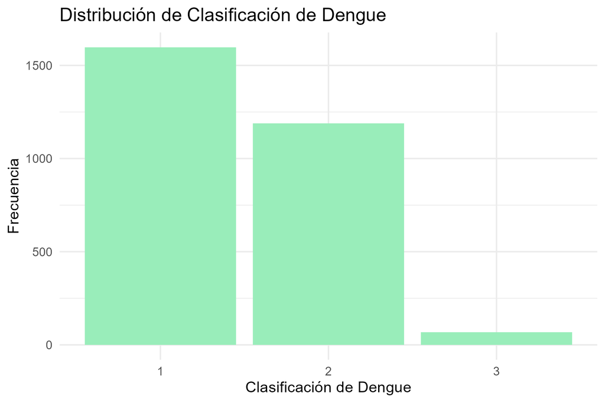

Por ultimo cabe mencionar que las observaciones correspondientes al dengue grave (nivel 3), las incluimos en el dengue con signos de alarma (nivel 2) por la poca cantidad de observaciones que habia en el dengue tipo 3 (68 observaciones) y ademas de esto para que todas nuestra variables fueran dicotomas.

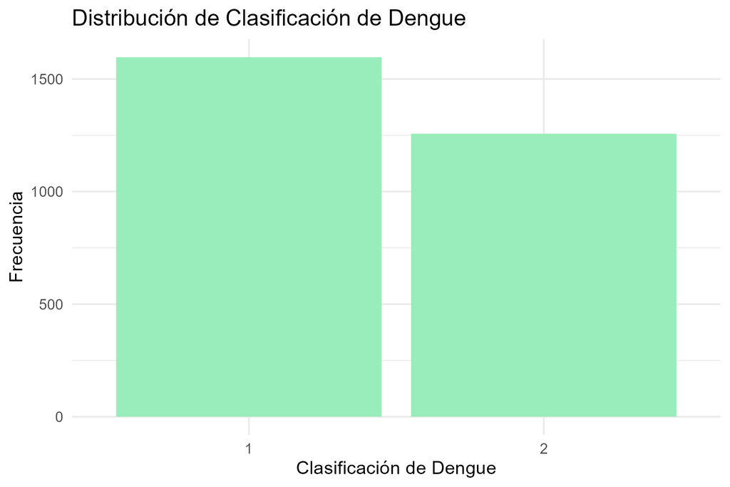

La prueba de chi-cuadrado, también conocida como prueba de independencia o prueba de bondad de ajuste, es una prueba estadística utilizada para determinar si existe una asociación significativa entre dos variables categóricas en una población. En el contexto de un análisis de correspondencia, la prueba de chi-cuadrado puede ser utilizada para evaluar la independencia entre las variables en la tabla de contingencia.

La hipótesis nula de la prueba de chi-cuadrado establece que no hay asociación entre las variables categóricas en la población, mientras que la hipótesis alternativa sugiere que hay una asociación significativa. El estadístico de prueba chi-cuadrado se calcula como la suma de los residuos al cuadrado dividida por los valores esperados bajo la hipótesis nula.

$$\begin{cases}
\begin{aligned}
&H_0: No\ existe\ una\ relacion\ significativa\ entre\ las\
variables\\
&H_a: Existe\ una\ relacion\ significativa\ entre\ las\ variables
\end{aligned}
\end{cases}$$

Significancia variables

| Variable | Valor_p |
| --- | --- |
| artralgia | 0.9438053 |
| dolrretroo | 0.2241499 |
| erupcionr | 0.2012671 |
| cefalea | 0.0982721 |
| malgias | 0.0274714 |
| hipotermia | 0.0045686 |
| hepatomeg | 0.0000007 |
| acum_liquievento | 0.0000000 |
| fiebre | 0.0000000 |
| hipotensio | 0.0000000 |
| aum_hemato | 0.0000000 |
| somnolenci | 0.0000000 |
| hem_mucosa | 0.0000000 |
| caida_plaq | 0.0000000 |
| vomito | 0.0000000 |
| dolor_abdo | 0.0000000 |

Tomando un $\alpha = 0.05$, teniendo suficiente evidencia estadistica para decir que las variables: artralgias,dolrretroo,erupcionr y cefalea no son significativas para explicar el comportamiento de la variable **clas_dengue**.

Estas son las variables resultantes:

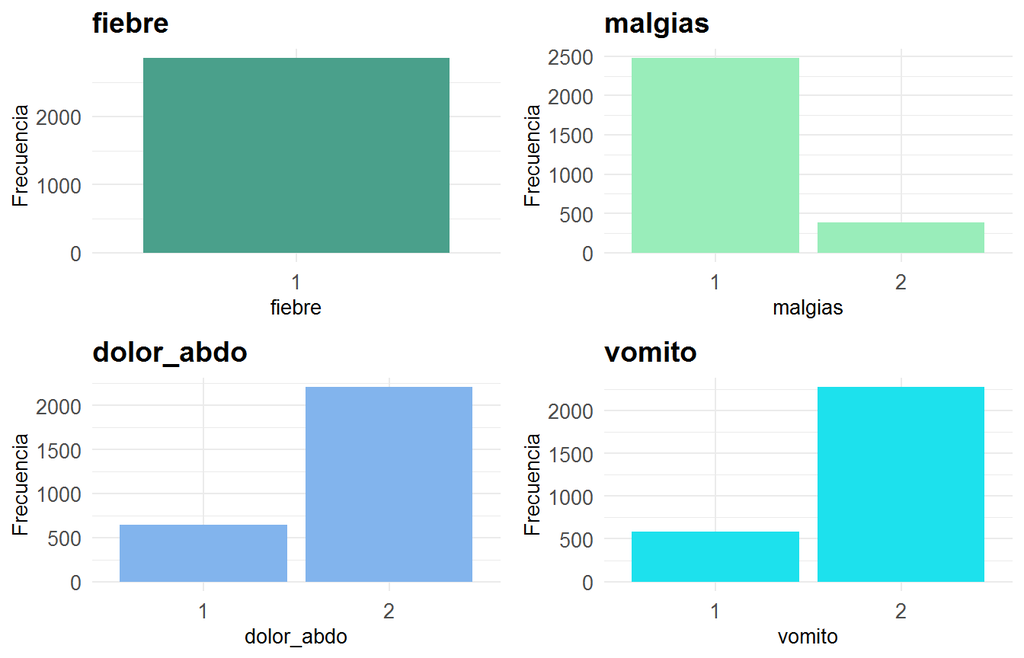

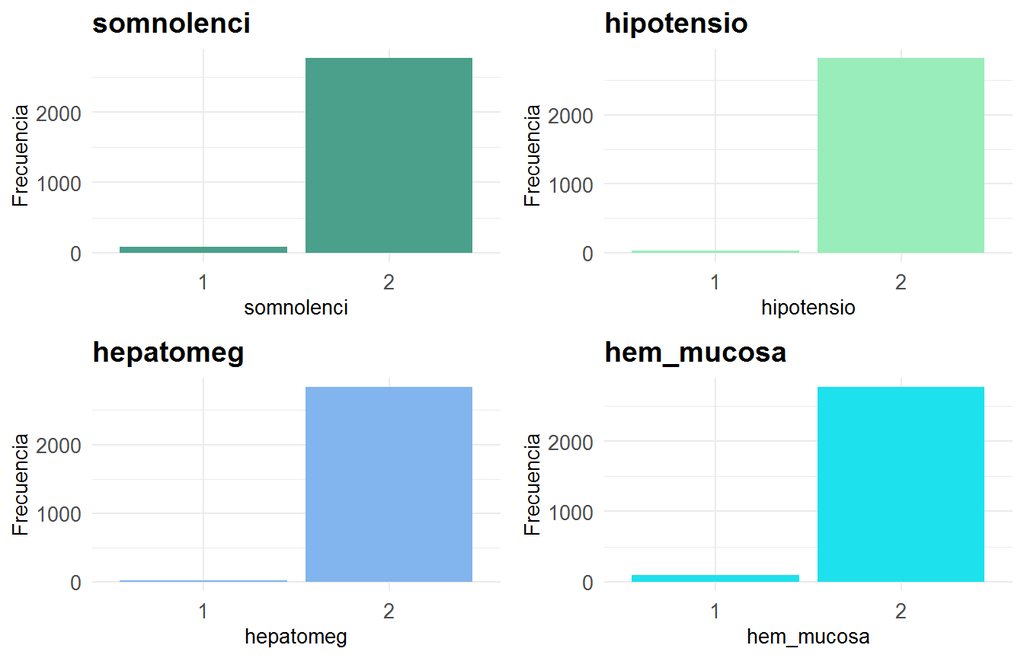

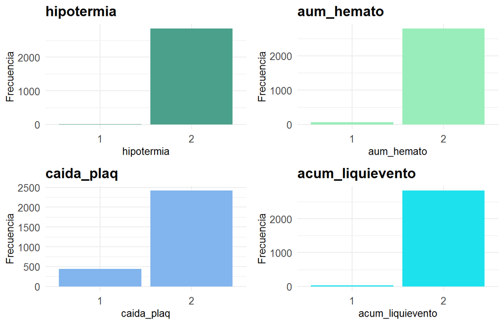

Como se puede ver en estos graficos todos los pacientes tienen fiebre, por lo tanto no tendria sentido meterla en el modelo ya que no se mueve entre ambos mundos (dengue sin signos de alarma y dengue con signos de alarma) y eso le daria un sesgo al modelo

Vomito

| . | 1 | 2 |
| --- | --- | --- |
| 1 | 0 | 1597 |
| 2 | 583 | 674 |

Dolor abdominal

| . | 1 | 2 |
| --- | --- | --- |
| 1 | 0 | 1597 |
| 2 | 649 | 608 |

Hemorragia mucosa

| . | 1 | 2 |
| --- | --- | --- |
| 1 | 0 | 1597 |
| 2 | 90 | 1167 |

Hipotermia

| . | 1 | 2 |
| --- | --- | --- |
| 1 | 0 | 1597 |
| 2 | 8 | 1249 |

Despues de analizar la base de datos y la información proporcionada, surge como pregunta de interes ¿Como optimizar la clasificación de pacientes que presentan dengue a partir de los sintomas que presentan?, esto permitiendo que su atención y uso de los recursos medicos disponibles sea más apropiada y aprovechada al maximo. Para poder responder a la interrogante y tomando en cuenta el análisis descriptivo de los datos, se plantean dos modelos donde uno corresponde a los sintomas comunes y otro a los sintomas poco comunes en pacientes con dengue (utilizando las variables que resultaron significativas en el test chi-cuadrado), para ambos la variable respuesta es **clas_dengue**, tanto la variable respuesta como las variables predictoras son de tipo binarias.

Dada la naturaleza del problema los modelos propuestos se definen como:

$$\begin{array}{c}
\mathbf{Y}_i \sim \operatorname{Bernoulli}\left(\theta_i\right), \quad
y_i=0,1 \quad i=1, \ldots, n \\
\beta \sim N\left(\mu, \sigma^2\right)
\end{array}$$

De donde su función de enlace,

$$\begin{aligned}
\operatorname{Logit}\left(\theta_i\right) & =\ln
\left(\frac{\theta_i}{1-\theta_i}\right)=\beta^T \cdot \mathbf{X} \\
\theta_i & =\frac{e^{\beta^T \mathbf{X}}}{1+e^{\beta^T} \mathbf{X}}
\end{aligned}$$

Ejecutado en el lenguaje de programación stan se obtiene que:

$$\begin{array}{lrrrrrrrrrrrr} & \text { mean } & \text { semean
} & \text { sd } & 2.5 \% & 25 \% & 50 \% & 75 \%
& 97.5 \% & \text { neff } & \text { Rhat } \\ \text {
beta[1] } & 162.23 & 1.97 & 60.59 & 57.63 & 118.57
& 157.46 & 200.97 & 291.64 & 946 & 1 \\ \text {
beta[2] } & -82.20 & 1.53 & 49.33 & -193.85 &
-112.78 & -75.08 & -43.59 & -11.35 & 1045 & 1 \\
\text { beta[3] } & -56.97 & 1.09 & 38.10 & -146.89
& -78.73 & -48.88 & -27.07 & -8.71 & 1223 & 1 \\
\text { beta[4] } & -45.70 & 1.03 & 34.30 & -131.48
& -64.64 & -37.33 & -18.64 & -5.12 & 1116 & 1 \\
\text { beta[5] } & -2.96 & 1.53 & 47.79 & -105.19 &
-30.36 & -0.91 & 25.88 & 89.45 & 977 & 1 \\ \text {
beta[6] } & 23.86 & 1.87 & 57.90 & -92.95 & -12.80
& 23.16 & 61.62 & 138.74 & 959 & 1
\end{array}$$

Ejecutado en el lenguaje de programación stan se obtiene que:

$$\begin{array}{lrrrrrrrrrr} & \text { mean } & \text {semean }
& \text { sd } & 2.5 \% & 25 \% & 50 \% & 75 \%
& 97.5 \% & \text { neff } & \text { Rhat } \\ \text { beta
}[1] & 170.48 & 1.99 & 56.80 & 71.06 & 129.62 &
167.05 & 206.78 & 292.37 & 817 & 1.01 \\ \text { beta
}[2] & -43.88 & 1.05 & 33.47 & -128.40 & -61.15
& -35.42 & -18.19 & -5.37 & 1013 & 1.01 \\ \text {
beta }[3] & -41.11 & 0.93 & 32.76 & -124.62 & -57.68
& -32.72 & -16.10 & -3.76 & 1228 & 1 .00 \\ \text {
beta }[4] & -45.69 & 1.20 & 34.08 & -132.44 & -63.04
& -36.65 & -19.30 & -2.21 & 807 & 1.00 \\ \text {
beta }[5] & -40.76 & 0.94 & 31.45 & -117.72 & -58.39
& -32.57 & -15.92 & -4.18 & 1123 & 1.00\end{array}$$

Continuando con la misma linea de reflexión, se escogieron tres criterios para comparar la calidad predictiva de los modelos:

El DIC (Deviance Information Criterion, por sus siglas en inglés) es una medida utilizada en la inferencia bayesiana y el modelado estadístico para evaluar la calidad de un modelo. Se basa en el principio de que un buen modelo debe ajustarse bien a los datos y, al mismo tiempo, ser parsimonioso.

Se expresa como:

$$D I C=-2 \log \left(f\left(y \mid \widehat{\theta}{\text {Bayes
}}\right)+2 P{\text {DIC }}\right)$$
Donde $\vec{\theta}{B a y e s}=E[\theta \mid y]$ y $P{D I C}$ es el número efectivo de parametros.

El valor del DIC se interpreta de manera relativa, es decir, se compara entre los modelos, los cuales estan ajustados a los mismos datos. Un modelo con un valor de DIC más bajo se considera preferible, lo que indica un mejor equilibrio entre el ajuste y la complejidad en comparación con otros modelos.

La curva ROC (Receiver Operating Characteristic) es una herramienta ampliamente utilizada para evaluar y visualizar el rendimiento de un clasificador en problemas de clasificación binaria. Esta curva representa gráficamente la relación entre la sensibilidad (tasa de verdaderos positivos) y la especificidad (tasa de verdaderos negativos) en diferentes puntos de corte del clasificador.

En el eje X de la curva ROC se representa la tasa de falsos positivos, que es la proporción de instancias negativas incorrectamente clasificadas como positivas. En el eje Y se representa la tasa de verdaderos positivos, que es la proporción de instancias positivas correctamente clasificadas como positivas.

Cuanto más cercana esté la curva ROC al vértice superior izquierdo del gráfico, mejor será el rendimiento del clasificador, ya que se alcanzarán altas tasas de verdaderos positivos con bajos falsos positivos. El área bajo la curva ROC (AUC-ROC) es una medida comúnmente utilizada para resumir el rendimiento general del clasificador: un valor cercano a 1 indica un buen rendimiento, mientras que un valor cercano a 0.5 indica un rendimiento aleatorio.

Al realizar la curva ROC y calcular el área debajo de ella se obtuvo:

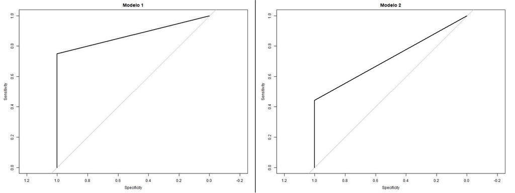

El modelo 1 cuenta con un mayor AUC-ROC, lo que significa que presenta un mejor rendimiento a la hora de clasificar en la clase de dengue a los pacientes frente al modelo 2.

El LOOCV (Leave-One-Out Cross-Validation) es una técnica de validación cruzada ampliamente utilizada en el campo del modelado estadístico. Consiste en dividir el conjunto de datos en n bloques, donde n es el número total de observaciones. En cada iteración, se ajusta el modelo utilizando n-1 bloques y se evalúa su rendimiento al predecir la observación excluida.

El LOOCV es especialmente útil cuando el tamaño del conjunto de datos es limitado. Proporciona una estimación precisa del rendimiento del modelo, ya que utiliza todos los datos disponibles en cada iteración. Además, el LOOCV evita el sesgo de subestimación que puede ocurrir con otras técnicas de validación cruzada.

Dentro de las medidas de decisión de LOOCV, se tomaron en cuenta elpd_loo, p_loo, looic.

**elpd_loo:** ELPD calculado utilizando LOOCV. Es una medida de la calidad de ajuste y la capacidad predictiva del modelo. Cuanto mayor sea el valor, mejor será el modelo en términos de ajuste y predicción.

**p_loo:** Medida de precisión de la estimación de ELPD utilizando LOOCV. Cuanto menor sea el valor, mayor será la precisión de la estimación.

**looic:** Información de criterio de información bayesiano (BIC) calculada utilizando LOOCV. Es una medida de la calidad de ajuste y la complejidad del modelo. Valores más bajos indican un mejor ajuste y modelos más parsimoniosos

Dado el formato de la estructura, es necesario realizar el cálculo de la exponencial de las estimaciones con el fin de facilitar su interpretación. Por lo tanto, podemos expresar que:

$$\begin{array}{c}\log
\left(\frac{\theta}{1-\theta}\right)=\boldsymbol{\beta} \cdot \mathbf{X}
\\ \log (\text { odds })=\beta \cdot \mathbf{X} \\ \text { odds
}=\mathrm{e}^{\beta \cdot \mathbf{X}}\end{array}$$

$$\begin{array}{lrrrrrrrr} & \text
{mean} & 2.5 \% & 97.5 \% \\ \text {beta[1]} &
2.854919\times10^{70} & 1.067557\times10^{25} &
4.546139\times10^{126} \\ \text {beta[2]} & 1.999832\times10^{-36}
& 6.486564\times10^{-85} & 1.176949\times10^{-5} \\ \text
{beta[3]} & 1.812355\times10^{-25} & 1.608731\times10^{-64}
& 1.649283\times10^{-4}
\\ \text {beta[4]} & 1.421485\times10^{-20} &
7.924311\times10^{-58} & 5.976023\times10^{-3}
\\ \text {beta[5]} & 5.181892\times10^{-2} &
2.072829\times10^{-46} & 7.041114\times10^{38}
\\ \text {beta[6]} & 2.3028536472\times10^{10} &
4.288722\times10^{-41} & 1.794801\times10^{60}
\end{array}$$

Como se demuestra en las investigaciones hechas por los expertos acerca de el dengue, ciertas patologias son indicativos fuertes de un tipo de dengue, lo cual da las indicaciones de que se posee un tipo de dengue en especifico dado que ya posee la enfermedad, y como vimos en la eleccion de modelos, los sintomas comunes ayudan mucho mas a predecir cual tipo de dengue tiene el paciente que los sintomas poco comunes ya que tal vez se puede llegar a asociar a otros problemas que tenga la persona. Por ultimo cabe resaltar que hay ciertas patologias que soy muy influyentes a la hora de determinar el tipo de dengue, lo cual se vio en el analisis del ODDS.

En el siguiente link se redirecciona a un repositorio donde se encuentra todo el trabajo realizado y los codigos empleados para su desarrollo:

**https://github.com/cristiancacz2311/Clasificacion_de_pacientes_con_Dengue-Bayesiana**

o puede usar el siguiente codigo QR:

[figure not shown]

- Alcaldía de Medellín. (n.d.). Alcaldía De Medellín. https://www.medellin.gov.co/irj/portal/medellin?NavigationTarget=contenido/6991-MEData-el-portal-de-datos-publicos-del-Municipio-de-Medellin
- Ametameric. (n.d.). https://pippin.gimp.org/ametameric/
- Padilla, J. C. P., Rojas, D. P. R., & Sáenz-Gómez, R. S. (n.d.). Dengue en colombia. Minsalud. https://www.minsalud.gov.co/sites/rid/Lists/BibliotecaDigital/RIDE/INEC/INV/Dengue en Colombia.pdf
- Dengue. (n.d.). Ministerio De Salud Y Proteccion Social. https://n9.cl/ozwdm
- Sosa, A. a. S., Ayala, F. A., Martínez De Cuellar, C. M. C., Borba, J. B., & Chamorro, G. C. (2012). Dengue guia del manejo clinico. Retrieved June 20, 2023, from https://iris.paho.org/bitstream/handle/10665.2/10101/9789996768422_esp.pdf?sequence=1&isAllowed=y
- Pando Ferrer, R., Ferrer, P. F., & Centro de Atención y Educación al Diabético de Bauta. (n.d.). Manifestaciones oftalmológicas del dengue, el zika y el chikungunya. Scielo. Retrieved June 20, 2023, from http://scielo.sld.cu/scielo.php?script=sci_arttext&pid=S0864-21762021000400008
- Dengue. (s. f.). OPS/OMS | Organización Panamericana de la Salud. https://n9.cl/nxtml
- World Health Organization: WHO & World Health Organization: WHO. (2023). Dengue y dengue grave. www.who.int. https://www.who.int/es/news-room/fact-sheets/detail/dengue-and-severe-dengue
- Síntomas y tratamiento del Dengue | CDC. (2021, 20 septiembre). Centers for Disease Control and Prevention. https://www.cdc.gov/dengue/es/symptoms/index.html
- Nrc, R. A. /. (2023, 17 mayo). Perú vive el peor brote de dengue del siglo. Aristegui Noticias. https://aristeguinoticias.com/1705/mundo/peru-vive-el-peor-brote-de-dengue-del-siglo/
- Antulio, H. R. (s. f.). Factores de riesgos asociados a la infección por dengue en San Mateo, Anzoátegui, Venezuela. http://scielo.sld.cu/scielo.php?script=sci_arttext&pid=S0864-21252011000300009